# Primo Homework

# 6.k: Quante delle nazioni identificate al punto 6.j esportano petrolio?

```r
# Conta quante nazioni con mortalità infantile ≥ 300 esportano petrolio
nazioni_petrolio_infmort_300 <- sum(nazioni$infmort >= 300 & nazioni$oil == "yes")

# Stampa il risultato
print(paste("Numero di nazioni con mortalità infantile ≥ 300 che esportano petrolio:", nazioni_petrolio_infmort_300))
```

```
## [1] "Numero di nazioni con mortalità infantile ≥ 300 che esportano petrolio: 2"
```

```r
### INFO ###:
#nazioni$infmort...: Questa condizione combina due verifiche: una per il tasso di mortalità
#                    infantile e l'altra per l'esportazione di petrolio.
#                    Restituisce TRUE solo per le righe che soddisfano entrambe le condizioni.

# sum(...): Somma i valori TRUE per contare quante nazioni soddisfano entrambe le condizioni.
```

## 6.l: Dividere la finestra grafica in 2 righe e 2 colonne. In ogni spazio, rappresentare con un boxplot la distribuzione della mortalità infantile condizionata alla regione geografica. Impostare lo stesso range sull’asse y ed il titolo del grafico.

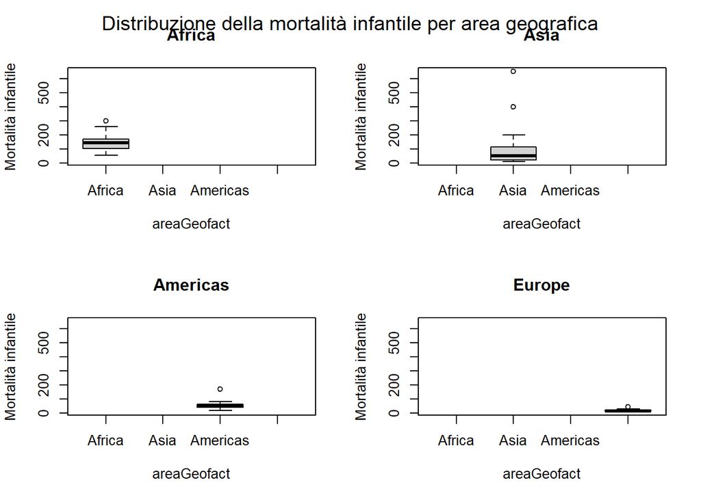

```r
# Divido la finestra grafica in due righe e due colonne
par(mfrow = c(2, 2))

# Imposto il range fisso per l'asse y
limiti_y <- range(nazioni$infmort)

# Boxplot Africa
boxplot(infmort ~ areaGeofact, data = subset(nazioni, areaGeofact == "Africa"),
        ylim = limiti_y, main = "Africa", ylab = "Mortalità infantile")

# Boxplot Asia
boxplot(infmort ~ areaGeofact, data = subset(nazioni, areaGeofact == "Asia"),
        ylim = limiti_y, main = "Asia", ylab = "Mortalità infantile")

# Boxplot Americas
boxplot(infmort ~ areaGeofact, data = subset(nazioni, areaGeofact == "Americas"),
        ylim = limiti_y, main = "Americas", ylab = "Mortalità infantile")

# Boxplot Europe
boxplot(infmort ~ areaGeofact, data = subset(nazioni, areaGeofact == "Europe"),
        ylim = limiti_y, main = "Europe", ylab = "Mortalità infantile")

# Titolo generale sopra tutti i boxplot
mtext("Distribuzione della mortalità infantile per area geografica", outer = TRUE, line = -2, cex = 1.2)
```

```r
# Resetto la finestra grafica normale
par(mfrow = c(1, 1))

### INFO ###:
# par(): Divide lo spazio grafico in 2 righe e 2 colonne
# range (): Trova il minimo e massimo dei valori di mortalità, così tutti i boxplot hanno lo stesso asse y
# subset(): Seleziona solo i dati di una certa area
# Ogni boxplot() ha il suo titolo (main) e etichetta y (ylab).

# Alla fine, par(mfrow = c(1, 1)) ripristina la finestra grafica normale
# (importantissimo dopo aver fatto grafici multipli!).
```

## 6.m: Rappresentare con un istogramma la distribuzione del reddito. Modificare l’etichetta dell’asse x con il nome della variabile ed eliminare il titolo.

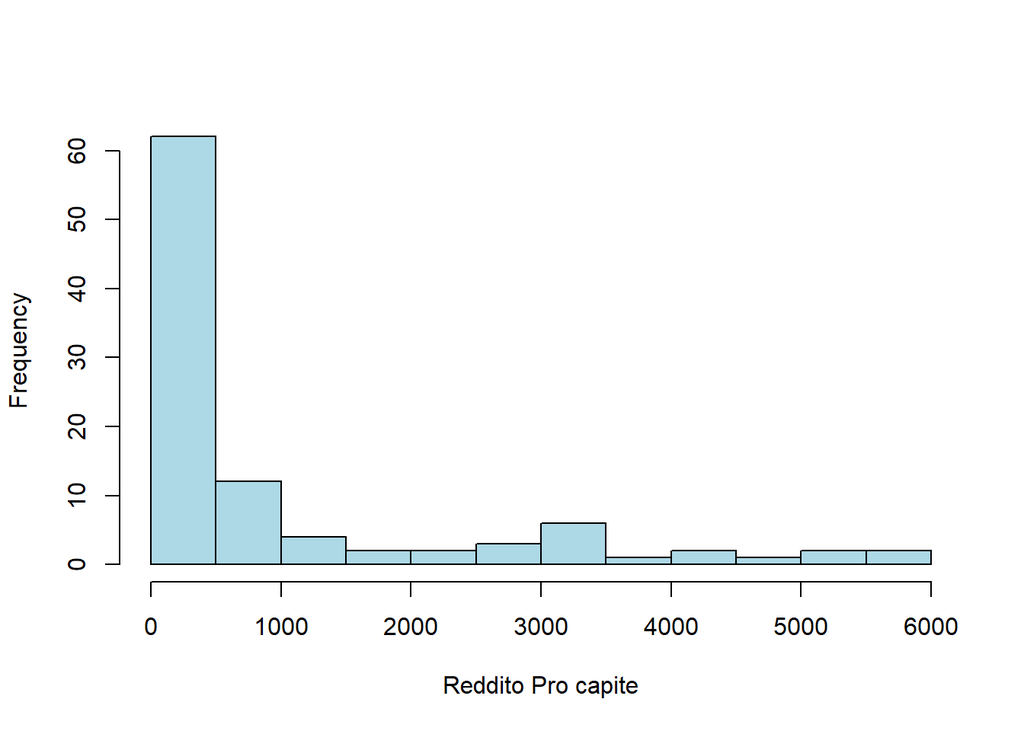

```r
hist(nazioni$reddito,
     xlab = "Reddito Pro capite",      # Etichetta asse x
     main = "",                        # Niente titolo
     col= "lightblue",
     border= "black")
```

```r
### INFO ###:
# hist(): Crea l'istogramma della variabile reddito
# xlab = "Reddito": Imposta il testo sull'asse orizzontale
# main = "": Elimina il titolo
# col = "" e border = "": sono aggiunte estetiche
```

## 6.n: Aggiungere al grafico precedente le mediane del reddito per area geografica utilizzando dei punti di colore diverso.

```r
# Ridisegno l'istogramma come prima
hist(nazioni$reddito,
     xlab = "Reddito",
     main = "",
     col = "lightblue",
     border = "black")

# Calcolo la mediana del reddito per ogni area geografica
mediane_reddito <- tapply(nazioni$reddito, nazioni$areaGeofact, median)

# Stampo le mediane per sicurezza
print(mediane_reddito)
```

```
##   Africa     Asia Americas   Europe
##      132      261      590     3292
```

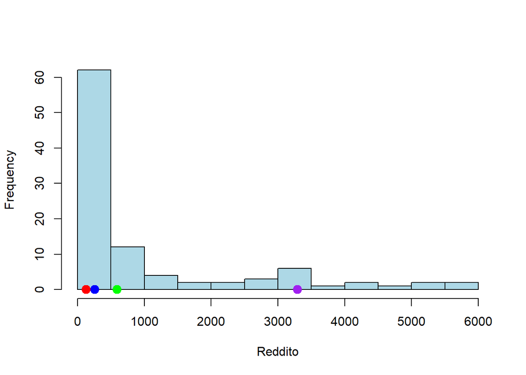

```r
# Aggiungo i punti delle mediane sull'istogramma
points(mediane_reddito,
       y = rep(0, length(mediane_reddito)),        # Metto i punti alla base (altezza 0)
       col = c("red", "blue", "green", "purple"),  # Colori diversi
       pch = 19,                                   # Tipo di punto: cerchietto pieno
       cex = 1.5)                                  # Dimensione del punto
```

```r
### INFO ###:
# tapply(...): Calcola la mediana del reddito per ciascuna area geografica
# points(): Aggiunge i punti sull'istogramma:  - y = 0: Perché li voglio alla base dell'istogramma.
#                                              - col = c(): Per usare colori diversi.
#                                              - pch = 19: Fa i punti pieni
#                                              - cex = 1.5: Ingrandisce i punti
```

## 6.o: Dividere la variabile reddito in classi utilizzando le seguenti categorie: “fino a 500”, “(500, 1500]”, “(1500, 4000]”, “4000 e più”. Salvare la nuova variabile in un oggetto chiamato redditoCat.

```r
# Creo la nuova variabile redditoCat
# Creo la variabile redditoCat
nazioni$redditoCat <- cut(nazioni$reddito,
                          breaks = c(0, 500, 1500, 4000, Inf),
                          labels = c("fino a 500", "(500, 1500]", "(1500, 4000]", "4000 e più"),
                          right = TRUE)

# Visualizzo le prime righe per confermare
head(nazioni[, c("nome", "reddito", "redditoCat")])
```

```
##        nome reddito   redditoCat
## 1 Australia    3426 (1500, 4000]
## 4   Belgium    3346 (1500, 4000]
## 5    Canada    4751   4000 e più
## 6   Denmark    5029   4000 e più
## 7   Finland    3312 (1500, 4000]
## 8    France    3403 (1500, 4000]
```

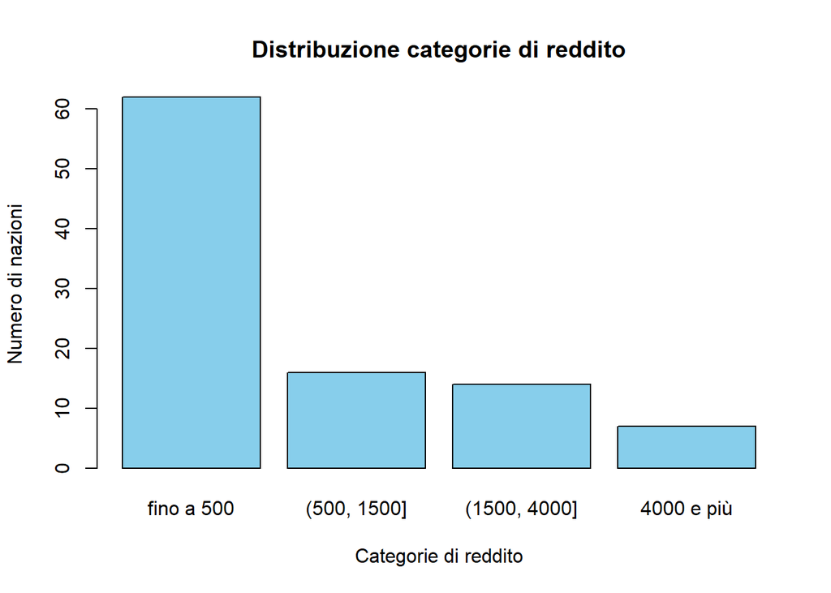

```r
# Barplot delle categorie di reddito
barplot(table(nazioni$redditoCat),
        main = "Distribuzione categorie di reddito",
        col = "skyblue",
        ylab = "Numero di nazioni",
        xlab = "Categorie di reddito")
```

```r
### INFO ###:
# cut(): Divide i valori di reddito secondo i limiti.
# labels = ...: Specifica il nome di ciascuna categoria.
# right = TRUE: Significa che l’intervallo include il bordo superiore.
```

## 6.p: Quante nazioni sono nella categoria “4000 e più”? E qual è la loro distribuzione per area geografica?

```r
# Conta e mostra la distribuzione delle nazioni con reddito ≥ 4000 per area geografica
distribuzione_areaGeo <- table(nazioni$areaGeofact[nazioni$redditoCat == "4000 e più"])

# Stampa il risultato
print(distribuzione_areaGeo)
```

```
##
##   Africa     Asia Americas   Europe
##        0        0        2        5
```

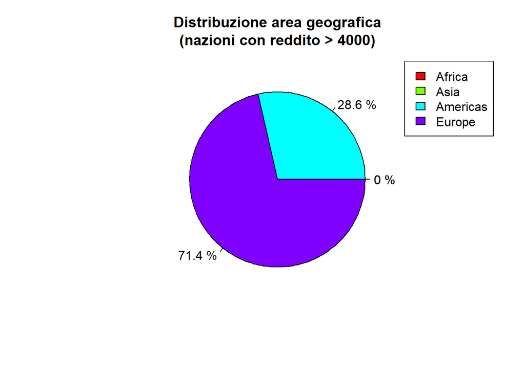

```r
# Calcola le percentuali
percentuali <- round(100 * distribuzione_areaGeo / sum(distribuzione_areaGeo), 1)

# Barplot a torta con percentuali
pie(distribuzione_areaGeo,
    labels = paste(percentuali, "%"),
    main = "Distribuzione area geografica\n(nazioni con reddito > 4000)",
    col = rainbow(length(distribuzione_areaGeo)))

# Aggiungo una legenda separata
legend("topright",
       legend = names(distribuzione_areaGeo),
       fill = rainbow(length(distribuzione_areaGeo)))
```

```r
### INFO ###:
# table([]): Filtra direttamente il dataframe per le nazioni con reddito ≥ 4000
#            e calcola la distribuzione delle aree geografiche in un'unica riga di codice.
```

## 6.q: Stampare le distribuzioni condizionate della variabile redditoCat rispetto all’esportazione di petrolio approssimandole a 2 cifre decimali.

```r
# Creo una tabella di contingenza redditoCat vs oil
tabella_reddito_oil <- table(nazioni$redditoCat, nazioni$oil)

# Calcolo le percentuali per ogni categoria di reddito
percentuali_reddito_oil <- prop.table(tabella_reddito_oil, margin = 1) * 100

# Arrotondo le percentuali a 2 cifre decimali
percentuali_reddito_oil <- round(percentuali_reddito_oil, 2)

# Stampo la tabella finale
print(percentuali_reddito_oil)
```

```
##
##                    no    yes
##   fino a 500    93.55   6.45
##   (500, 1500]   87.50  12.50
##   (1500, 4000]  85.71  14.29
##   4000 e più   100.00   0.00
```

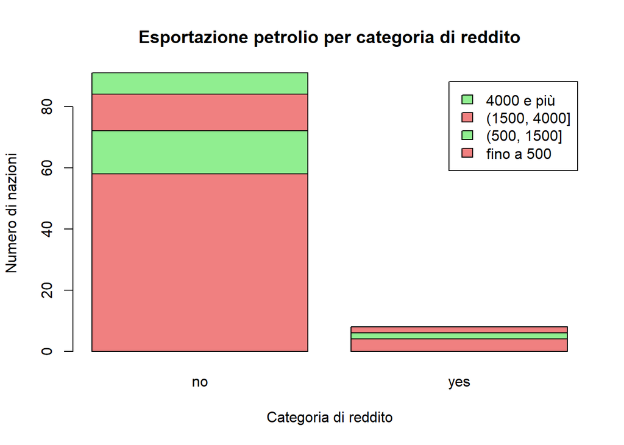

```r
# Grafico a barre impilate redditoCat vs oil
barplot(tabella_reddito_oil,
        beside = FALSE,
        legend.text = TRUE,
        col = c("lightcoral", "lightgreen"),
        main = "Esportazione petrolio per categoria di reddito",
        ylab = "Numero di nazioni",
        xlab = "Categoria di reddito")
```

```r
### INFO ###:
# table(): Crea una tabella incrociata tra categoria di reddito e petrolio.
# prop.table(): Calcola la percentuale riga per riga (quindi ogni riga fa il 100%).
# round(): Arrotonda ogni valore a 2 cifre decimali.
```